# A graphical summary of your random forest

randomForestExplainer

June 06, 2019

## Details of your forest

```
##
## Call:
##  randomForest(formula = as.factor(age_at_test) ~ ., data = twins_data_met_dob,      importance = TRUE)
##                Type of random forest: classification
##                      Number of trees: 500
## No. of variables tried at each split: 27
##
##         OOB estimate of  error rate: 86.18%
## Confusion matrix:
##    33 34 35 36 37 38 39 40 41 42 43 44 45 46 47 48 49 50 51 52 53 54 55 56
## 33  0  0  0  0  0  0  0  0  0  0  0  0  1  0  0  1  1  1  0  2  0  0  0  0
## 34  0  0  0  1  0  0  0  0  0  0  0  0  2  2  2  1  5  0  2  1  0  0  0  0
## 35  0  0  1  0  0  1  0  0  1  0  0  2  1  2  1  3  6  2  1  1  0  0  0  0
## 36  0  0  0  0  0  2  0  0  0  2  3  0  2  0  4  0  4  2  2  0  0  1  1  0
## 37  0  0  0  0  0  1  0  0  1  1  2  2  4  1  2  6  1  3  2  0  2  2  2  0
```

[output cut: 49 more lines]

## Distribution of minimal depth

The plot below shows the distribution of minimal depth among the trees of your forest. Note that:

- the mean of the distribution is marked by a vertical bar with a value label on it (the scale for it is different than for the rest of the plot),
- the scale of the X axis goes from zero to the maximum number of trees in which any variable was used for splitting.

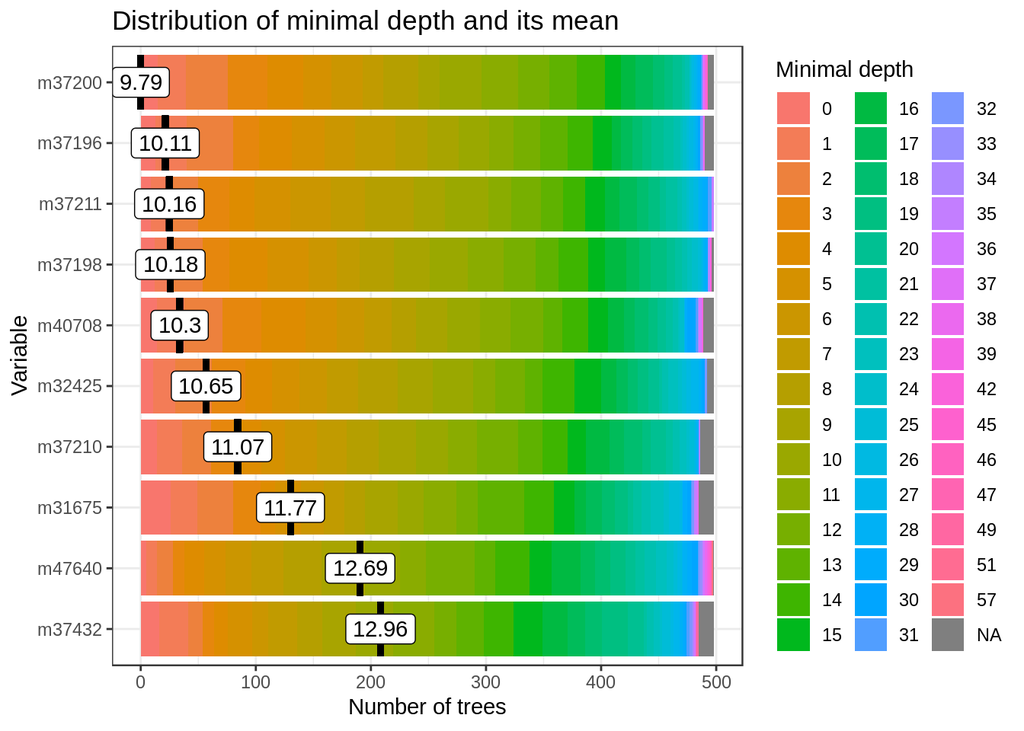

Minimal depth for a variable in a tree equals to the depth of the node which splits on that variable and is the closest to the root of the tree. If it is low than a lot of observations are divided into groups on the basis of this variable

## Importance measures

Below you can explore the measures of importance for all variables in the forest:

|  | variable | mean_min_depth | no_of_nodes | accuracy_decrease | gini_decrease | no_of_trees | times_a_root | p_value |
| --- | --- | --- | --- | --- | --- | --- | --- | --- |
| 1 | m1105 | 16.09859437751 | 1571 | 3.86135061564973e-05 | 7.1481980241864 | 481 | 0 | 0.984796266829028 |
| 2 | m1107 | 15.394578313253 | 1650 | 4.26915376224276e-05 | 7.87193594915999 | 483 | 0 | 0.580900837720937 |
| 3 | m1110 | 14.8746987951807 | 1684 | 2.80258810379443e-05 | 7.87653810895602 | 486 | 0 | 0.264370881501998 |
| 4 | m1114 | 15.6867469879518 | 1688 | 2.52378841583765e-05 | 8.01481024208669 | 478 | 0 | 0.233401759843653 |
| 5 | m1118 | 15.4034136546185 | 1579 | 2.20649715047418e-05 | 7.35376572881014 | 485 | 0 | 0.975277827072601 |
| 6 | m1121 | 15.413453815261 | 1550 | 9.91993964009158e-05 | 7.13759058409304 | 475 | 1 | 0.996441930446504 |
| 7 | m1123 | 14.2116465863454 | 1691 | 2.68565144631751e-05 | 8.21763305940633 | 490 | 0 | 0.211577264559974 |
| 8 | m1124 | 15.1740963855422 | 1710 | 5.11819547398264e-05 | 8.24032361075241 | 479 | 0 | 0.103113972277491 |
| 9 | m1125 | 15.0301204819277 | 1591 | 0.000117185321101594 | 7.82340538856591 | 478 | 1 | 0.952080127861226 |
| 10 | m1126 | 14.6975903614458 | 1716 | 1.76724436794348e-05 | 8.06456182524556 | 490 | 0 | 0.0792885415928426 |

[output cut: 746 more lines]

## Multi-way importance plot

The multi-way importance plot shows the relation between three measures of importance and labels 10 variables which scored best when it comes to these three measures (i.e. for which the sum of the ranks for those measures is the lowest).

The first multi-way importance plot focuses on three importance measures that derive from the structure of trees in the forest:

- mean depth of first split on the variable,
- number of trees in which the root is split on the variable,
- the total number of nodes in the forest that split on that variable.

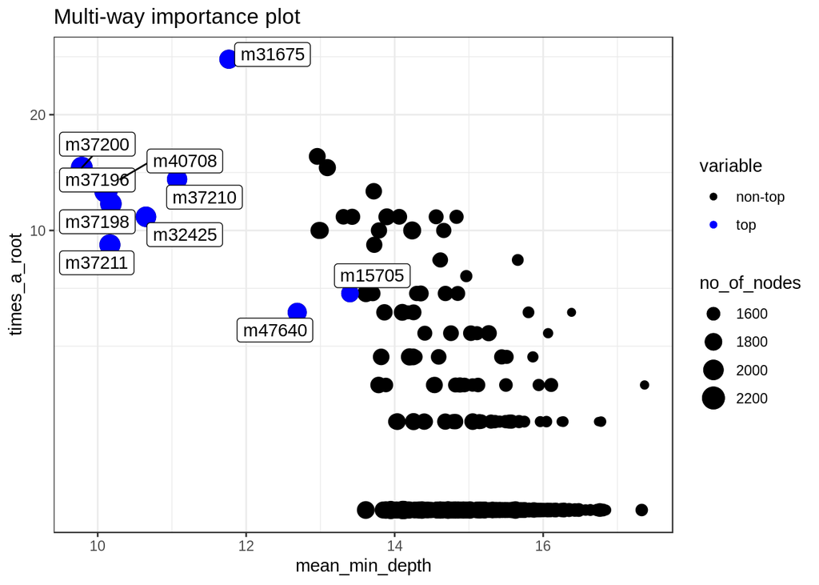

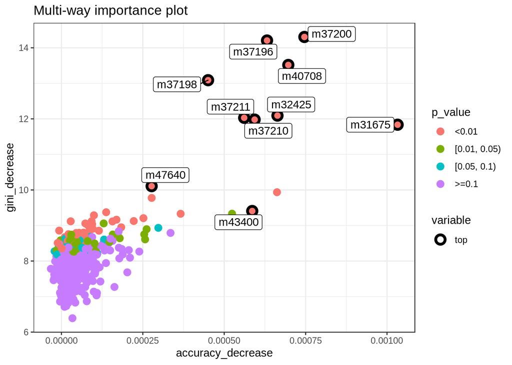

## Compare importance measures

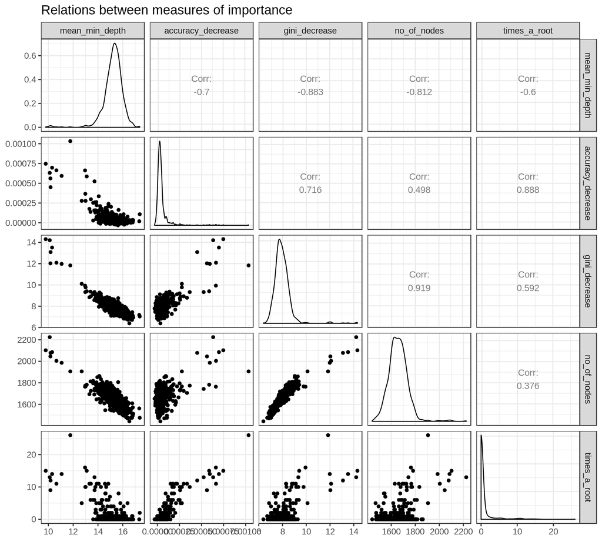

## Compare rankings of variables

The plot below shows bilateral relations between the rankings of variables according to chosen importance measures. This approach might be useful as rankings are more evenly spread than corresponding importance measures. This may also more clearly show where the different measures of importance disagree or agree.

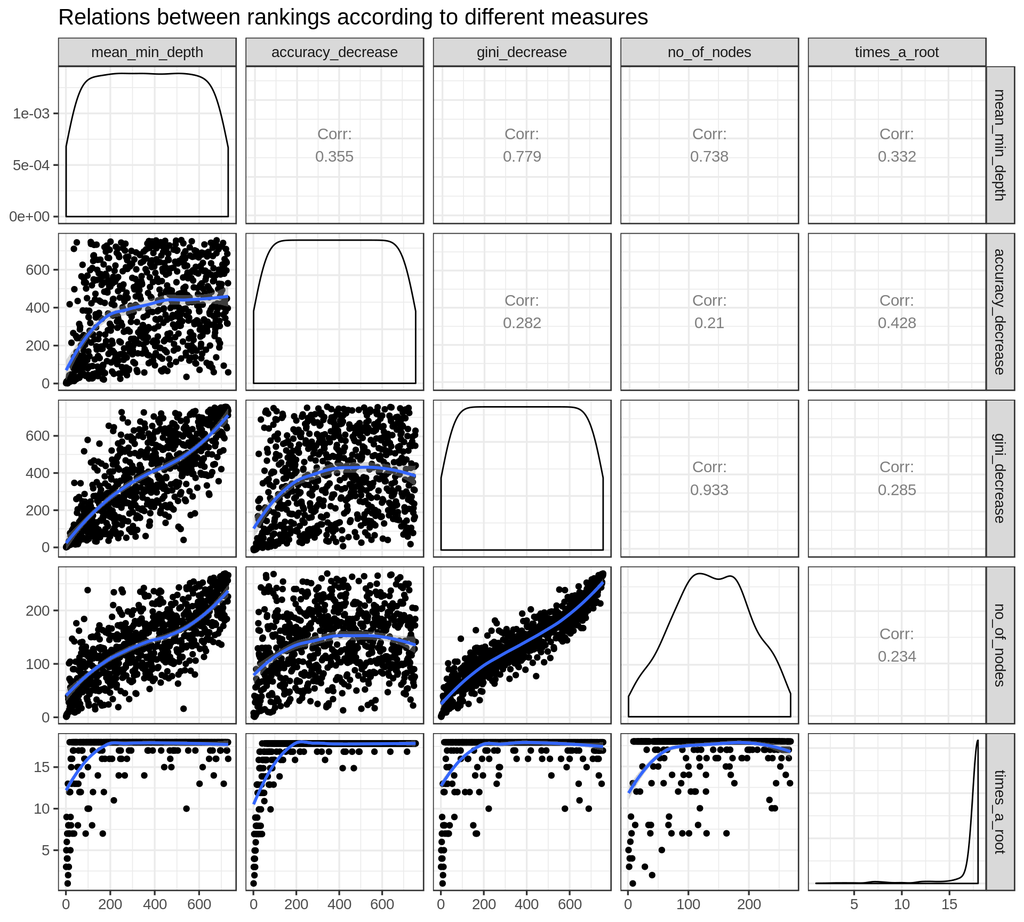